# Staying or Straying

PSY 120L Reproducible Analysis Report

Author

Silvia Kachadoorian

Published

June 7, 2026

## About This Report

*This report presents the statistical analyses conducted to examine how attachment style and relationship initiation context influence willingness to commit in romantic relationships. Participants were randomly assigned to read either an online dating or an in-person relationship initiation vignette and then completed measures of attachment style and relationship commitment. Attachment style was assessed using the Experiences in Close Relationships Scale–Short Form (ECR-S), which measures dimensions of attachment anxiety and attachment avoidance, while relationship commitment was measured using the Commitment Level Subscale of the Investment Model Scale.*

*The primary goal of the study was to compare willingness to commit among individuals with secure and insecure attachment patterns and, more specifically, to examine how attachment anxiety and attachment avoidance influence commitment in relationships initiated online versus in person. Based on attachment theory, it was expected that individuals with more secure attachment patterns would report greater willingness to commit than individuals with more insecure attachment patterns. It was also hypothesized that commitment levels may differ across relationship initiation contexts, with online dating potentially being associated with lower commitment than in-person relationship formation.*

*To evaluate these hypotheses, factorial analyses were conducted examining the effects of relationship initiation context and attachment style on relationship commitment. Descriptive statistics, confidence intervals, effect sizes, and significance tests are presented throughout this report to aid in the interpretation of the findings and to better understand how attachment-related processes influence commitment in contemporary romantic relationships.*

## Study Overview

*The purpose of this study was to examine how attachment style and relationship initiation context influence willingness to commit in romantic relationships. Attachment theory suggests that individuals with secure attachment patterns are generally more comfortable with intimacy and long-term commitment, whereas individuals with insecure attachment patterns, particularly those high in attachment avoidance, may be less willing to commit. Participants were randomly assigned to read either an online dating or an in-person relationship initiation vignette and then completed measures of attachment style and relationship commitment. It was hypothesized that individuals with more secure attachment patterns would report greater willingness to commit than individuals with more insecure attachment patterns. Additionally, it was expected that relationships initiated through online dating would be associated with lower commitment than relationships initiated in person. This study aimed to determine whether personal attachment processes or relationship initiation context are stronger predictors of romantic commitment.*

## Setup and Software Environment

*This report was created using R and RStudio. Data preparation and analyses were conducted using the tidyverse package for data management, psych for descriptive statistics, afex for ANOVA analyses, emmeans for estimated marginal means and confidence intervals. All analyses and outputs were generated through an R Markdown document to provide a reproducible record of the statistical procedures.*

**Load Packages**

```r
library(tidyverse)  # data manipulation + plotting
library(psych)      # scale construction + reliability
library(afex)       # ANOVA models + effect sizes
library(emmeans)    # estimated marginal means + confidence intervals
```

## Data Source and Analysis Dataset

*The data analyzed in this report were collected from undergraduate students who participated in a study examining romantic relationship commitment. Participants were randomly assigned to read either an online dating or an in-person relationship initiation vignette and then completed measures of attachment style and relationship commitment. The final analysis dataset included participants with complete data on relationship initiation context, attachment style, and commitment scores. Key variables included relationship initiation context (online vs. in-person), attachment anxiety (low vs. high), attachment avoidance (low vs. high), and willingness to commit, as measured by the Commitment Level Subscale of the Investment Model Scale.*

### Import Dataset

```r
study_raw <- read_csv("data/staying_straying_data.csv")
```

### Check Imported Dataset

```r
dim(study_raw)
```

```
[1] 57 27
```

```r
names(study_raw)
```

```
 [1] "ResponseId"          "DistributionChannel" "Consent"
 [4] "Commit_1"            "Commit_2"            "Commit_3"
 [7] "Commit_4"            "Commit_5"            "Commit_6"
[10] "Commit_7"            "Commit_8"            "ECRS_1"
[13] "ECRS_2"              "ECRS_3"              "ECRS_4"
[16] "ECRS_5"              "ECRS_6"              "ECRS_7"
[19] "ECRS_8"              "ECRS_9"              "ECRS_10"
[22] "ECRS_11"             "ECRS_12"             "zodiac"
[25] "age"                 "gender"              "condition"
```

```r
head(study_raw)
```

```
# A tibble: 6 × 27
  ResponseId     DistributionChannel Consent Commit_1 Commit_2 Commit_3 Commit_4
  <chr>          <chr>                 <dbl>    <dbl>    <dbl>    <dbl>    <dbl>
1 R_33jar6hZfXT… email                     1        7        8        6        3
2 R_3YTqJ9eK2Nl… email                     1        9        9        9        1
3 R_5Gkbu0b4OR5… email                     1        9        9        5        3
4 R_7E0Dy5fon0s… email                     1        9        9        8        1
5 R_5EEjq5YU90w… email                     1        6        6        6        1
6 R_1KVKyaSSdhL… email                     1        6        7        7        2
# ℹ 20 more variables: Commit_5 <dbl>, Commit_6 <dbl>, Commit_7 <dbl>,
#   Commit_8 <dbl>, ECRS_1 <dbl>, ECRS_2 <dbl>, ECRS_3 <dbl>, ECRS_4 <dbl>,
#   ECRS_5 <dbl>, ECRS_6 <dbl>, ECRS_7 <dbl>, ECRS_8 <dbl>, ECRS_9 <dbl>,
#   ECRS_10 <dbl>, ECRS_11 <dbl>, ECRS_12 <dbl>, zodiac <dbl>, age <dbl>,
#   gender <dbl>, condition <dbl>
```

*The output above was used to verify that the dataset imported correctly into R. The dim() function displays the number of observations and variables contained in the dataset, allowing for confirmation of the dataset size. The names() function lists all variable names and provides an opportunity to identify the variables that will be used in subsequent analyses. Finally, the head() function displays the first several rows of the dataset, allowing for a preliminary inspection of the data structure, coding, and values before conducting statistical analyses.*

### Create Analysis Dataset

```r
study_vars <- c(
  "condition", "zodiac", "age", "gender",

  "Commit_1", "Commit_2", "Commit_3", "Commit_4",
  "Commit_5", "Commit_6", "Commit_7", "Commit_8",
  "ECRS_1", "ECRS_2", "ECRS_3", "ECRS_4", "ECRS_5", "ECRS_6",
  "ECRS_7", "ECRS_8", "ECRS_9", "ECRS_10", "ECRS_11", "ECRS_12"

)



study_data <- study_raw %>%
  select(all_of(study_vars)) %>%
  mutate(
    across(everything(), as.numeric)
  )
```

### Check Analysis Dataset

```r
length(study_vars)
```

```
[1] 24
```

```r
dim(study_data)
```

```
[1] 57 24
```

```r
names(study_data)
```

```
 [1] "condition" "zodiac"    "age"       "gender"    "Commit_1"  "Commit_2"
 [7] "Commit_3"  "Commit_4"  "Commit_5"  "Commit_6"  "Commit_7"  "Commit_8"
[13] "ECRS_1"    "ECRS_2"    "ECRS_3"    "ECRS_4"    "ECRS_5"    "ECRS_6"
[19] "ECRS_7"    "ECRS_8"    "ECRS_9"    "ECRS_10"   "ECRS_11"   "ECRS_12"
```

*The output above was used to verify the structure of the analysis dataset after selecting the variables relevant to the study. The length() function confirmed that 24 variables were included in the analysis dataset. The dim() function indicated that the dataset contained 57 participants and 24 variables. Finally, the names() function displayed the names of all variables retained for analysis, including demographic variables (e.g., age and gender), the relationship initiation condition variable, commitment scale items, and attachment style questionnaire items. This step ensured that all necessary variables were present and correctly prepared for subsequent analyses.*

## Variable Preparation

*Prior to analysis, the study variables were prepared and coded for statistical testing. Demographic variables and experimental condition assignments were reviewed to ensure accurate coding. Items from the Commitment Level Subscale of the Investment Model Scale and the Experiences in Close Relationships Scale–Short Form (ECR-S) were examined, and any reverse-scored items were recoded according to the scoring instructions for each measure. Composite scores were then calculated by combining the relevant questionnaire items to create overall measures of relationship commitment and attachment dimensions. These prepared variables were subsequently used in the descriptive statistics and inferential analyses reported below.*

### Prepare Participant ID and Experimental Condition

```r
study_data <- study_data %>%
  mutate(
    id = row_number(),
    condition = factor(
      condition,
      levels = c(0, 1),
      labels = c("Online", "In Person")
    )
  )
```

*The code above was used to create a unique identification number for each participant and to prepare the experimental condition variable for analysis. The row_number() function assigned a sequential ID to each participant, allowing individual responses to be tracked throughout the analysis process without using personally identifying information. The condition variable was then converted to a factor, with values coded as “Online” and “In Person” to represent the two relationship initiation contexts. Recoding the condition variable as a factor ensured that it would be treated as a categorical independent variable in subsequent statistical analyses.*

### Check Experimental Condition Coding

```r
study_data %>%
  count(condition) %>%
  knitr::kable(
    col.names = c("Condition", "n")
  )
```

| Condition | n |
| --- | --- |
| Online | 28 |
| In Person | 25 |
| NA | 4 |

*The output above was used to verify that the experimental condition variable was coded correctly and to examine the distribution of participants across conditions. A total of 28 participants were assigned to the Online condition and 25 participants were assigned to the In Person condition, indicating a relatively balanced distribution across the two groups. Four cases contained missing values for the condition variable and were identified for further review. This step ensured that the experimental manipulation was properly coded before conducting statistical analyses.*

### Check Prepared Analysis Dataset

```r
dim(study_data)
```

```
[1] 57 25
```

```r
names(study_data)
```

```
 [1] "condition" "zodiac"    "age"       "gender"    "Commit_1"  "Commit_2"
 [7] "Commit_3"  "Commit_4"  "Commit_5"  "Commit_6"  "Commit_7"  "Commit_8"
[13] "ECRS_1"    "ECRS_2"    "ECRS_3"    "ECRS_4"    "ECRS_5"    "ECRS_6"
[19] "ECRS_7"    "ECRS_8"    "ECRS_9"    "ECRS_10"   "ECRS_11"   "ECRS_12"
[25] "id"
```

*The output above was used to verify the final structure of the prepared analysis dataset. The dim() function indicated that the dataset contained 57 participants and 25 variables. The names() function confirmed that all variables necessary for the analyses were present, including the experimental condition variable, demographic variables (age and gender), commitment questionnaire items, attachment questionnaire items, and the participant identification variable. This final check ensured that the dataset was properly organized and ready for scoring procedures and statistical analyses.*

### Reverse-Code Scale Items

*Several items from the attachment and commitment measures were reverse-scored prior to computing scale scores. Reverse coding ensures that all items are oriented in the same direction, such that higher scores consistently reflect higher levels of the construct being measured. For the ECR-S, items 1, 5, 8, and 9 were reverse-scored, while items 4, 5, and 8 from the Commitment Level Subscale were reverse-scored according to the scale scoring instructions. New variables were created for the reverse-scored items and used in subsequent scale calculations.*

*The output below was used to verify that the reverse-scoring procedure was performed correctly. Comparison of the original and reverse-scored variables shows that higher original scores were converted to lower reverse-scored values and vice versa. For example, an original score of 7 on ECRS_1 became a reverse-scored value of 1, while an original score of 1 on Commit_4 became a reverse-scored value of 9. This check confirmed that the reverse-coded variables were computed accurately before calculating composite scale scores.*

```r
study_data <- study_data %>%
  mutate(
    ECRS_1r = 8 - ECRS_1,
    ECRS_5r = 8 - ECRS_5,
    ECRS_8r = 8 - ECRS_8,
    ECRS_9r = 8 - ECRS_9,


    Commit_4r = 10 - Commit_4,
    Commit_5r = 10 - Commit_5,
    Commit_8r = 10 - Commit_8

  )
```

### Check Reverse Coding

```r
study_data %>%
  select(ECRS_1, ECRS_1r, Commit_4, Commit_4r) %>%
  head(10) %>%
  knitr::kable()
```

| ECRS_1 | ECRS_1r | Commit_4 | Commit_4r |
| --- | --- | --- | --- |
| 6 | 2 | 3 | 7 |
| 7 | 1 | 1 | 9 |
| 5 | 3 | 3 | 7 |
| 7 | 1 | 1 | 9 |
| 7 | 1 | 1 | 9 |
| 6 | 2 | 2 | 8 |
| 6 | 2 | 2 | 8 |
| 7 | 1 | 1 | 9 |
| 5 | 3 | 2 | 8 |
| 7 | 1 | 2 | 8 |

### Create Scale Scores

*Composite scale scores were created for attachment insecurity, attachment anxiety, attachment avoidance, and relationship commitment. Following the scoring procedures for the Experiences in Close Relationships Scale–Short Form (ECR-S), separate mean scores were calculated for overall attachment insecurity as well as the anxiety and avoidance subscales. Mean scores were also calculated for the Commitment Level Subscale of the Investment Model Scale after reverse-scored items were recoded. The rowMeans() function was used to compute participant-level averages across the relevant items while allowing for occasional missing responses. Higher scores on the attachment scales indicated greater attachment insecurity, anxiety, or avoidance, whereas higher scores on the commitment scale reflected greater willingness to commit in romantic relationships. These composite variables were used in all subsequent descriptive and inferential analyses.*

```r
# Define ECR-S total attachment insecurity items
ECRS_items <- c(
  "ECRS_1r", "ECRS_2", "ECRS_3", "ECRS_4", "ECRS_5r", "ECRS_6",
  "ECRS_7", "ECRS_8r", "ECRS_9r", "ECRS_10", "ECRS_11", "ECRS_12"
)

# Define ECR-S anxiety items
ECRS_anxiety_items <- c(
  "ECRS_2", "ECRS_4", "ECRS_6", "ECRS_8r", "ECRS_10", "ECRS_12"
)

# Define ECR-S avoidance items
ECRS_avoidance_items <- c(
  "ECRS_1r", "ECRS_3", "ECRS_5r", "ECRS_7", "ECRS_9r", "ECRS_11"
)

# Define commitment items
commitment_items <- c(
  "Commit_1", "Commit_2", "Commit_3", "Commit_4r",
  "Commit_5r", "Commit_6", "Commit_7", "Commit_8r"
)

# Create scale scores
study_data <- study_data %>%
  mutate(
    ECRS_scale = rowMeans(across(all_of(ECRS_items)), na.rm = TRUE),
    ECRS_anxiety = rowMeans(across(all_of(ECRS_anxiety_items)), na.rm = TRUE),
    ECRS_avoidance = rowMeans(across(all_of(ECRS_avoidance_items)), na.rm = TRUE),
    commitment = rowMeans(across(all_of(commitment_items)), na.rm = TRUE)
  )
```

### Check Scale Scores

```r
study_data %>%
  select(
    ECRS_scale,
    ECRS_anxiety,
    ECRS_avoidance,
    commitment
  ) %>%
  summary()
```

```
   ECRS_scale     ECRS_anxiety   ECRS_avoidance    commitment
 Min.   :1.500   Min.   :1.667   Min.   :1.000   Min.   :4.000
 1st Qu.:2.833   1st Qu.:3.333   1st Qu.:2.000   1st Qu.:6.000
 Median :3.417   Median :4.000   Median :2.583   Median :6.875
 Mean   :3.330   Mean   :4.041   Mean   :2.590   Mean   :6.765
 3rd Qu.:3.750   3rd Qu.:4.667   3rd Qu.:3.167   3rd Qu.:7.625
 Max.   :4.917   Max.   :5.833   Max.   :4.833   Max.   :9.000
 NA's   :8       NA's   :8       NA's   :9       NA's   :8
```

```r
study_data %>%
  summarise(
    ECRS_scale_missing = mean(is.na(ECRS_scale)),
    ECRS_anxiety_missing = mean(is.na(ECRS_anxiety)),
    ECRS_avoidance_missing = mean(is.na(ECRS_avoidance)),
    commitment_missing = mean(is.na(commitment))
  ) %>%
  knitr::kable()
```

| ECRS_scale_missing | ECRS_anxiety_missing | ECRS_avoidance_missing | commitment_missing |
| --- | --- | --- | --- |
| 0.1403509 | 0.1403509 | 0.1578947 | 0.1403509 |

*The output above provides descriptive statistics for the composite scale scores used in the analyses. Overall attachment insecurity scores ranged from 1.50 to 4.92 (M = 3.33), while attachment anxiety scores ranged from 1.67 to 5.83 (M = 4.04) and attachment avoidance scores ranged from 1.00 to 4.83 (M = 2.59). Relationship commitment scores ranged from 4.00 to 9.00, with participants reporting relatively high levels of commitment on average (M = 6.77). The presence of a small number of missing values was noted for each scale, but composite scores were successfully calculated for the majority of participants. These results suggest adequate variability in the study variables and support their use in subsequent analyses.*

### Create Attachment Groups

*To facilitate group comparisons, participants were categorized into low and high attachment groups using median splits on the overall attachment insecurity score, attachment anxiety score, and attachment avoidance score. The median values were 3.42 for overall attachment insecurity, 4.00 for attachment anxiety, and 2.58 for attachment avoidance. Participants scoring at or below the median were classified into the low group, whereas participants scoring above the median were classified into the high group.*

```r
# Compute median ECR-S scores
ECRS_median <- median(study_data$ECRS_scale, na.rm = TRUE)
ECRS_anxiety_median <- median(study_data$ECRS_anxiety, na.rm = TRUE)
ECRS_avoidance_median <- median(study_data$ECRS_avoidance, na.rm = TRUE)

# Create low/high attachment groups
study_data <- study_data %>%
  mutate(
    ECRS_msplit = if_else(ECRS_scale <= ECRS_median, "Low", "High"),
    ECRS_msplit = factor(ECRS_msplit, levels = c("Low", "High")),

    ECRS_anxiety_msplit = if_else(ECRS_anxiety <= ECRS_anxiety_median, "Low", "High"),
    ECRS_anxiety_msplit = factor(ECRS_anxiety_msplit, levels = c("Low", "High")),

    ECRS_avoidance_msplit = if_else(ECRS_avoidance <= ECRS_avoidance_median, "Low", "High"),
    ECRS_avoidance_msplit = factor(ECRS_avoidance_msplit, levels = c("Low", "High"))
  )

# Print medians
ECRS_median
```

```
[1] 3.416667
```

```r
ECRS_anxiety_median
```

```
[1] 4
```

```r
ECRS_avoidance_median
```

```
[1] 2.583333
```

```r
# Check group sizes
study_data %>%
  count(ECRS_msplit) %>%
  knitr::kable()
```

| ECRS_msplit | n |
| --- | --- |
| Low | 27 |
| High | 22 |
| NA | 8 |

```r
study_data %>%
  count(ECRS_anxiety_msplit) %>%
  knitr::kable()
```

| ECRS_anxiety_msplit | n |
| --- | --- |
| Low | 26 |
| High | 23 |
| NA | 8 |

```r
study_data %>%
  count(ECRS_avoidance_msplit) %>%
  knitr::kable()
```

| ECRS_avoidance_msplit | n |
| --- | --- |
| Low | 24 |
| High | 24 |
| NA | 9 |

*The resulting group sizes were relatively balanced. For overall attachment insecurity, 27 participants were classified as low insecurity and 22 as high insecurity, with 8 missing cases. For attachment anxiety, 26 participants were classified as low anxiety and 23 as high anxiety, with 8 missing cases. Finally, for attachment avoidance, 24 participants were classified as low avoidance and 24 as high avoidance, with 9 missing cases. These grouping variables were subsequently used in the factorial ANOVA analyses examining the relationship between attachment style, relationship initiation context, and willingness to commit.*

### Check Scale Reliability

*Before conducting the primary analyses, the internal consistency reliability of each multi-item scale was evaluated. Reliability analyses were conducted using Cronbach’s alpha and McDonald’s omega, two commonly used measures of internal consistency. Higher reliability coefficients indicate that the items within a scale are measuring the same underlying construct and can therefore be combined into a composite score. Reliability was assessed for the overall ECR-S Attachment Insecurity scale, the Attachment Anxiety and Attachment Avoidance subscales, and the Commitment scale.*

```r
# Create item-only data frames for each multi-item rating scale
ECRS_item_df <- study_data %>%
  select(all_of(ECRS_items))

ECRS_anxiety_item_df <- study_data %>%
  select(all_of(ECRS_anxiety_items))

ECRS_avoidance_item_df <- study_data %>%
  select(all_of(ECRS_avoidance_items))

commitment_item_df <- study_data %>%
  select(all_of(commitment_items))

# Compute internal consistency estimates
ECRS_alpha <- psych::alpha(ECRS_item_df)
```

```
Some items ( ECRS_2 ECRS_8r ECRS_10 ECRS_12 ) were negatively correlated with the first principal component and
probably should be reversed.
To do this, run the function again with the 'check.keys=TRUE' option
```

```r
ECRS_omega <- psych::omega(ECRS_item_df, plot = FALSE)

ECRS_anxiety_alpha <- psych::alpha(ECRS_anxiety_item_df)
ECRS_anxiety_omega <- psych::omega(ECRS_anxiety_item_df, plot = FALSE)

ECRS_avoidance_alpha <- psych::alpha(ECRS_avoidance_item_df)
ECRS_avoidance_omega <- psych::omega(ECRS_avoidance_item_df, plot = FALSE)

commitment_alpha <- psych::alpha(commitment_item_df)
commitment_omega <- psych::omega(commitment_item_df, plot = FALSE)

# Print only alpha and omega coefficients
tibble(
  scale = c(
    "ECR-S Attachment Insecurity",
    "ECR-S Attachment Anxiety",
    "ECR-S Attachment Avoidance",
    "Commitment"
  ),
  alpha = c(
    ECRS_alpha$total$raw_alpha,
    ECRS_anxiety_alpha$total$raw_alpha,
    ECRS_avoidance_alpha$total$raw_alpha,
    commitment_alpha$total$raw_alpha
  ),
  omega = c(
    ECRS_omega$omega.tot,
    ECRS_anxiety_omega$omega.tot,
    ECRS_avoidance_omega$omega.tot,
    commitment_omega$omega.tot
  )
) %>%
  knitr::kable(digits = 2)
```

| scale | alpha | omega |
| --- | --- | --- |
| ECR-S Attachment Insecurity | 0.63 | 0.81 |
| ECR-S Attachment Anxiety | 0.59 | 0.62 |
| ECR-S Attachment Avoidance | 0.78 | 0.89 |
| Commitment | 0.77 | 0.89 |

*The reliability coefficients are presented in the table above. The ECR-S Attachment Insecurity scale demonstrated acceptable internal consistency (a = .63, w= .81), while the Attachment Anxiety subscale showed somewhat lower reliability (a = .59, w = .62). The Attachment Avoidance subscale exhibited good reliability (a = .78, w = .89), and the Commitment scale also demonstrated good internal consistency (a = .77, w = .89). Overall, the results suggest that the attachment avoidance and commitment measures were sufficiently reliable for use in subsequent analyses, whereas results involving attachment anxiety should be interpreted with somewhat greater caution due to its lower internal consistency.*

## Descriptive Statistics

*Descriptive statistics were calculated for the primary study variables to examine their distributions and central tendencies prior to conducting inferential analyses. Means, standard deviations, medians, ranges, and measures of skewness and kurtosis were computed for attachment insecurity, attachment anxiety, attachment avoidance, and relationship commitment. These statistics provide an overview of participant responses and help determine whether the variables exhibit sufficient variability for subsequent analyses.*

### Scale Score Descriptives

```r
study_data %>%
  select(
    ECRS_scale,
    ECRS_anxiety,
    ECRS_avoidance,
    commitment
  ) %>%
  psych::describe() %>%
  knitr::kable(digits = 2)
```

|  | vars | n | mean | sd | median | trimmed | mad | min | max | range | skew | kurtosis | se |
| --- | --- | --- | --- | --- | --- | --- | --- | --- | --- | --- | --- | --- | --- |
| ECRS_scale | 1 | 49 | 3.33 | 0.67 | 3.42 | 3.36 | 0.62 | 1.50 | 4.92 | 3.42 | -0.47 | 0.50 | 0.10 |
| ECRS_anxiety | 2 | 49 | 4.04 | 0.93 | 4.00 | 4.06 | 0.99 | 1.67 | 5.83 | 4.17 | -0.21 | -0.18 | 0.13 |
| ECRS_avoidance | 3 | 48 | 2.59 | 0.94 | 2.58 | 2.55 | 0.86 | 1.00 | 4.83 | 3.83 | 0.39 | -0.20 | 0.14 |
| commitment | 4 | 49 | 6.77 | 1.23 | 6.88 | 6.77 | 1.11 | 4.00 | 9.00 | 5.00 | -0.15 | -0.54 | 0.18 |

*The descriptive statistics for the primary study variables are presented in the table above. Participants reported moderate levels of overall attachment insecurity (M = 3.33, SD = 0.67), relatively high levels of attachment anxiety (M = 4.04, SD = 0.93), and lower levels of attachment avoidance (M = 2.59, SD = 0.94). Relationship commitment scores were generally high, with an average score of 6.77 (SD = 1.23) on the 9-point scale. Skewness and kurtosis values were relatively small for all variables, suggesting that the distributions did not substantially deviate from normality and were appropriate for use in the planned ANOVA analyses.*

### Sample Composition by Age, Gender, and Relationship

```r
study_data %>%
  summarise(
    mean_age = mean(age, na.rm = TRUE),
    sd_age = sd(age, na.rm = TRUE),
    min_age = min(age, na.rm = TRUE),
    max_age = max(age, na.rm = TRUE)
  ) %>%
  knitr::kable(
    digits = 2,
    col.names = c("Mean", "SD", "Minimum", "Maximum"),
    caption = "Sample Age: Mean, Standard Deviation, and Range"
  )
```

Sample Age: Mean, Standard Deviation, and Range

| Mean | SD | Minimum | Maximum |
| --- | --- | --- | --- |
| 21.69 | 1.61 | 19 | 28 |

```r
study_data %>%
  count(gender) %>%
  arrange(gender) %>%
  mutate(percent = round(100 * n / sum(n), 1)) %>%
  knitr::kable(
    col.names = c("Gender", "n", "Percent"),
    caption = "Sample Composition by Gender"
  )
```

Sample Composition by Gender

| Gender | n | Percent |
| --- | --- | --- |
| 1 | 5 | 8.8 |
| 2 | 43 | 75.4 |
| NA | 9 | 15.8 |

*The tables above summarize the demographic characteristics of the sample. Participants ranged in age from 19 to 28 years old (M = 21.69, SD = 1.61), indicating that the sample primarily consisted of young adults. Gender data showed that 43 participants (75.4%) were coded as Gender 2, 5 participants (8.8%) were coded as Gender 1, and 9 participants (15.8%) had missing gender data. Overall, the sample was predominantly composed of participants in the Gender 2 category, with a relatively small proportion of participants in the Gender 1 category.*

## Correlations Among the DVs

*Pearson correlation analyses were conducted to examine the relationships among the primary continuous study variables, including overall attachment insecurity, attachment anxiety, attachment avoidance, and relationship commitment. Correlation coefficients provide information about the strength and direction of associations between variables and help identify patterns that may be relevant for interpreting subsequent analyses. These analyses were conducted prior to the ANOVA to better understand how the attachment dimensions relate to one another and to relationship commitment.*

```r
# Correlations for the main continuous study variables
psych::corr.test(
  study_data %>%
    select(
      ECRS_scale,
      ECRS_anxiety,
      ECRS_avoidance,
      commitment
    )
)
```

```
Call:psych::corr.test(x = study_data %>% select(ECRS_scale, ECRS_anxiety,
    ECRS_avoidance, commitment))
Correlation matrix
               ECRS_scale ECRS_anxiety ECRS_avoidance commitment
ECRS_scale           1.00         0.70           0.71      -0.27
ECRS_anxiety         0.70         1.00           0.01       0.04
ECRS_avoidance       0.71         0.01           1.00      -0.40
commitment          -0.27         0.04          -0.40       1.00
Sample Size
               ECRS_scale ECRS_anxiety ECRS_avoidance commitment
ECRS_scale             49           49             48         49
ECRS_anxiety           49           49             48         49
ECRS_avoidance         48           48             48         48
commitment             49           49             48         49
Probability values (Entries above the diagonal are adjusted for multiple tests.)
               ECRS_scale ECRS_anxiety ECRS_avoidance commitment
ECRS_scale           0.00         0.00           0.00       0.17
ECRS_anxiety         0.00         0.00           1.00       1.00
ECRS_avoidance       0.00         0.97           0.00       0.02
commitment           0.06         0.79           0.01       0.00

 To see confidence intervals of the correlations, print with the short=FALSE option
```

## Primary Analyses

*To test the study hypotheses, a series of factorial analyses of variance (ANOVAs) were conducted examining the effects of relationship initiation context and attachment style on relationship commitment. Relationship initiation context (Online vs. In Person) served as the experimental independent variable, while attachment style was examined using median-split groupings derived from the ECR-S measures. The primary dependent variable was willingness to commit, as measured by the Commitment Level Subscale of the Investment Model Scale. The analyses focused on evaluating both main effects and interaction effects to determine whether commitment differed across relationship initiation contexts, attachment groups, or combinations of these factors.*

### **Commitment Model (total ECRS split)**

*The first ANOVA examined whether willingness to commit differed as a function of relationship initiation context (Online vs. In Person), overall attachment insecurity (Low vs. High), and the interaction between these variables. Participants were categorized into low and high attachment insecurity groups using a median split on the overall ECR-S score.*

```r
a1_commitment <- afex::aov_ez(
  id = "id",
  dv = "commitment",
  between = c("condition", "ECRS_msplit"),
  data = study_data
)

# Print the ANOVA table
a1_commitment
```

```
Anova Table (Type 3 tests)

Response: commitment
                 Effect    df  MSE    F  ges p.value
1             condition 1, 45 1.50 0.30 .007    .588
2           ECRS_msplit 1, 45 1.50 1.76 .038    .192
3 condition:ECRS_msplit 1, 45 1.50 0.73 .016    .397
---
Signif. codes:  0 '***' 0.001 '**' 0.01 '*' 0.05 '+' 0.1 ' ' 1
```

*The ANOVA results indicated that there was no significant main effect of relationship initiation context on willingness to commit, F(1, 45) = 0.30, p = .588, ges = .007. Participants in the Online and In Person conditions reported similar levels of commitment. There was also no significant main effect of overall attachment insecurity, F(1, 45) = 1.76, p = .192, ges = .038, suggesting that participants classified as low or high in attachment insecurity did not differ significantly in their commitment scores. Finally, the interaction between relationship initiation context and attachment insecurity was not significant, F(1, 45) = 0.73, p = .397, ges = .016, indicating that the effect of relationship initiation context on commitment did not depend on participants’ level of attachment insecurity.*

```r
emmeans(a1_commitment, ~ condition)
```

```
 condition emmean    SE df lower.CL upper.CL
 Online      6.82 0.234 45     6.34     7.29
 In Person   6.62 0.268 45     6.08     7.16

Results are averaged over the levels of: ECRS_msplit
Confidence level used: 0.95
```

```r
emmeans(a1_commitment, ~ ECRS_msplit)
```

```
 ECRS_msplit emmean    SE df lower.CL upper.CL
 Low           6.95 0.240 45     6.47     7.44
 High          6.48 0.263 45     5.95     7.01

Results are averaged over the levels of: condition
Confidence level used: 0.95
```

```r
emmeans(a1_commitment, ~ condition * ECRS_msplit)
```

```
 condition ECRS_msplit emmean    SE df lower.CL upper.CL
 Online    Low           7.20 0.307 45     6.59     7.82
 In Person Low           6.70 0.370 45     5.96     7.45
 Online    High          6.43 0.354 45     5.71     7.14
 In Person High          6.54 0.388 45     5.76     7.32

Confidence level used: 0.95
```

*Estimated marginal means were examined to aid interpretation of the ANOVA results. Participants in the Online condition reported slightly higher commitment scores (M = 6.82, 95% CI [6.34, 7.29]) than participants in the In Person condition (M = 6.62, 95% CI [6.08, 7.16]), although this difference was not statistically significant. Participants classified as low in attachment insecurity reported somewhat higher commitment (M = 6.95, 95% CI [6.47, 7.44]) than those classified as high in attachment insecurity (M = 6.48, 95% CI [5.95, 7.01]), but this difference was also not statistically significant.*

*Examination of the cell means showed that participants in the Online/Low Insecurity condition reported the highest levels of commitment (M = 7.20, 95% CI [6.59, 7.82]), whereas participants in the Online/High Insecurity condition reported the lowest levels of commitment (M = 6.43, 95% CI [5.71, 7.14]). However, the overlapping confidence intervals and nonsignificant interaction effect indicate that these differences were not large enough to support the conclusion that relationship initiation context and attachment insecurity jointly influenced willingness to commit.*

### **Commitment** Model (ECRS Anxiety)

*A second 2 × 2 between-subjects ANOVA was conducted to examine whether willingness to commit differed as a function of relationship initiation context (Online vs. In Person), attachment anxiety (Low vs. High), and the interaction between these variables. Participants were categorized into low and high attachment anxiety groups using a median split on the ECR-S attachment anxiety subscale. Relationship commitment served as the dependent variable.*

```r
# 2x2 between-subjects ANOVA predicting commitment scores
# DV: commitment
# Factors: condition and ECR-S attachment anxiety group
a2_commitment_anxiety <- afex::aov_ez(
  id = "id",
  dv = "commitment",
  between = c("condition", "ECRS_anxiety_msplit"),
  data = study_data
)

# Print the ANOVA table
a2_commitment_anxiety
```

```
Anova Table (Type 3 tests)

Response: commitment
                         Effect    df  MSE    F   ges p.value
1                     condition 1, 45 1.59 0.52  .011    .474
2           ECRS_anxiety_msplit 1, 45 1.59 0.04 <.001    .837
3 condition:ECRS_anxiety_msplit 1, 45 1.59 0.27  .006    .603
---
Signif. codes:  0 '***' 0.001 '**' 0.01 '*' 0.05 '+' 0.1 ' ' 1
```

*The ANOVA results indicated that there was no significant main effect of relationship initiation context on willingness to commit, F(1, 45) = 0.52, p = .474, ges = .011. Participants in the Online and In Person conditions reported similar levels of commitment. There was also no significant main effect of attachment anxiety, F(1, 45) = 0.04, p = .837, ges < .001, suggesting that participants classified as low or high in attachment anxiety did not differ significantly in their willingness to commit. Finally, the interaction between relationship initiation context and attachment anxiety was not significant, F(1, 45) = 0.27, p = .603, ges = .006, indicating that the effect of relationship initiation context on commitment did not depend on participants’ level of attachment anxiety. Overall, these findings suggest that attachment anxiety was not associated with willingness to commit in this sample.*

```r
emmeans(a2_commitment_anxiety, ~ condition)
```

```
 condition emmean    SE df lower.CL upper.CL
 Online      6.87 0.238 45     6.39     7.35
 In Person   6.61 0.278 45     6.05     7.17

Results are averaged over the levels of: ECRS_anxiety_msplit
Confidence level used: 0.95
```

```r
emmeans(a2_commitment_anxiety, ~ ECRS_anxiety_msplit)
```

```
 ECRS_anxiety_msplit emmean    SE df lower.CL upper.CL
 Low                   6.78 0.248 45     6.28     7.28
 High                  6.70 0.269 45     6.16     7.24

Results are averaged over the levels of: condition
Confidence level used: 0.95
```

```r
emmeans(a2_commitment_anxiety, ~ condition * ECRS_anxiety_msplit)
```

```
 condition ECRS_anxiety_msplit emmean    SE df lower.CL upper.CL
 Online    Low                   6.81 0.337 45     6.13     7.49
 In Person Low                   6.74 0.364 45     6.01     7.47
 Online    High                  6.93 0.337 45     6.25     7.61
 In Person High                  6.47 0.420 45     5.63     7.32

Confidence level used: 0.95
```

*Estimated marginal means were examined to further interpret the ANOVA results. Participants in the Online condition reported slightly higher commitment scores (M = 6.87, 95% CI [6.39, 7.35]) than participants in the In Person condition (M = 6.61, 95% CI [6.05, 7.17]), although this difference was not statistically significant. Similarly, participants classified as low in attachment anxiety reported commitment levels (M = 6.78, 95% CI [6.28, 7.28]) that were very similar to those classified as high in attachment anxiety (M = 6.70, 95% CI [6.16, 7.24]).*

*Examination of the cell means showed that participants in the Online/High Anxiety condition reported the highest commitment scores (M = 6.93, 95% CI [6.25, 7.61]), whereas participants in the In Person/High Anxiety condition reported the lowest commitment scores (M = 6.47, 95% CI [5.63, 7.32]). However, the confidence intervals overlapped substantially across all conditions, consistent with the nonsignificant main effects and interaction observed in the ANOVA. These findings suggest that neither attachment anxiety nor relationship initiation context was meaningfully associated with willingness to commit in this sample.*

### **Commitment** Model (ECRS Avoidance)

*A third 2 × 2 between-subjects ANOVA was conducted to examine whether willingness to commit differed as a function of relationship initiation context (Online vs. In Person), attachment avoidance (Low vs. High), and the interaction between these variables. Participants were categorized into low and high attachment avoidance groups using a median split on the ECR-S attachment avoidance subscale. Relationship commitment served as the dependent variable. Because attachment avoidance is theoretically associated with discomfort with intimacy and dependence, it was expected that participants with higher avoidance would report lower levels of commitment.*

```r
# 2x2 between-subjects ANOVA predicting commitment scores
# DV: commitment
# Factors: condition and ECR-S attachment avoidance group
a3_commitment_avoidance <- afex::aov_ez(
  id = "id",
  dv = "commitment",
  between = c("condition", "ECRS_avoidance_msplit"),
  data = study_data
)

# Print the ANOVA table
a3_commitment_avoidance
```

```
Anova Table (Type 3 tests)

Response: commitment
                           Effect    df  MSE      F   ges p.value
1                       condition 1, 44 1.40   0.59  .013    .445
2           ECRS_avoidance_msplit 1, 44 1.40 5.58 *  .112    .023
3 condition:ECRS_avoidance_msplit 1, 44 1.40   0.04 <.001    .845
---
Signif. codes:  0 '***' 0.001 '**' 0.01 '*' 0.05 '+' 0.1 ' ' 1
```

*The ANOVA results indicated that there was no significant main effect of relationship initiation context on willingness to commit, F(1, 44) = 0.59, p = .445, ges = .013. Participants in the Online and In Person conditions reported similar levels of commitment. However, there was a significant main effect of attachment avoidance, F(1, 44) = 5.58, p = .023, ges = .112. Participants classified as low in attachment avoidance reported significantly greater willingness to commit than participants classified as high in attachment avoidance. The interaction between relationship initiation context and attachment avoidance was not significant, F(1, 44) = 0.04, p = .845, ges < .001, indicating that the relationship between attachment avoidance and commitment was similar across both the Online and In Person conditions. Overall, these findings suggest that attachment avoidance, rather than relationship initiation context, was an important predictor of willingness to commit in romantic relationships.*

```r
emmeans(a3_commitment_avoidance, ~ condition)
```

```
 condition emmean    SE df lower.CL upper.CL
 Online      6.91 0.228 44     6.45     7.37
 In Person   6.65 0.259 44     6.12     7.17

Results are averaged over the levels of: ECRS_avoidance_msplit
Confidence level used: 0.95
```

```r
emmeans(a3_commitment_avoidance, ~ ECRS_avoidance_msplit)
```

```
 ECRS_avoidance_msplit emmean    SE df lower.CL upper.CL
 Low                     7.19 0.245 44     6.69     7.68
 High                    6.37 0.243 44     5.88     6.86

Results are averaged over the levels of: condition
Confidence level used: 0.95
```

```r
emmeans(a3_commitment_avoidance, ~ condition * ECRS_avoidance_msplit)
```

```
 condition ECRS_avoidance_msplit emmean    SE df lower.CL upper.CL
 Online    Low                     7.29 0.317 44     6.65     7.92
 In Person Low                     7.09 0.375 44     6.33     7.84
 Online    High                    6.54 0.329 44     5.88     7.20
 In Person High                    6.20 0.357 44     5.48     6.92

Confidence level used: 0.95
```

*Estimated marginal means were examined to further interpret the significant main effect of attachment avoidance. Participants in the Online condition reported slightly higher commitment scores (M = 6.91, 95% CI [6.45, 7.37]) than participants in the In Person condition (M = 6.65, 95% CI [6.12, 7.17]), although this difference was not statistically significant. In contrast, participants classified as low in attachment avoidance reported substantially higher commitment scores (M = 7.19, 95% CI [6.69, 7.68]) than participants classified as high in attachment avoidance (M = 6.37, 95% CI [5.88, 6.86]), consistent with the significant main effect observed in the ANOVA.*

*Examination of the cell means showed that participants in the Online/Low Avoidance condition reported the highest levels of commitment (M = 7.29, 95% CI [6.65, 7.92]), whereas participants in the In Person/High Avoidance condition reported the lowest levels of commitment (M = 6.20, 95% CI [5.48, 6.92]). However, the differences between the Online and In Person conditions were relatively small within both avoidance groups, and the interaction effect was not statistically significant. These findings suggest that lower attachment avoidance was associated with greater willingness to commit regardless of whether the relationship was initiated online or in person.*

## Figures

*The following figures display the estimated marginal means for commitment scores across relationship initiation conditions (online vs. in-person) and attachment groups. Error bars represent 95% confidence intervals. These visualizations complement the ANOVA results by illustrating patterns of main effects and interactions among the study variables.*

### Commitment (total ECRS) Interaction Plot

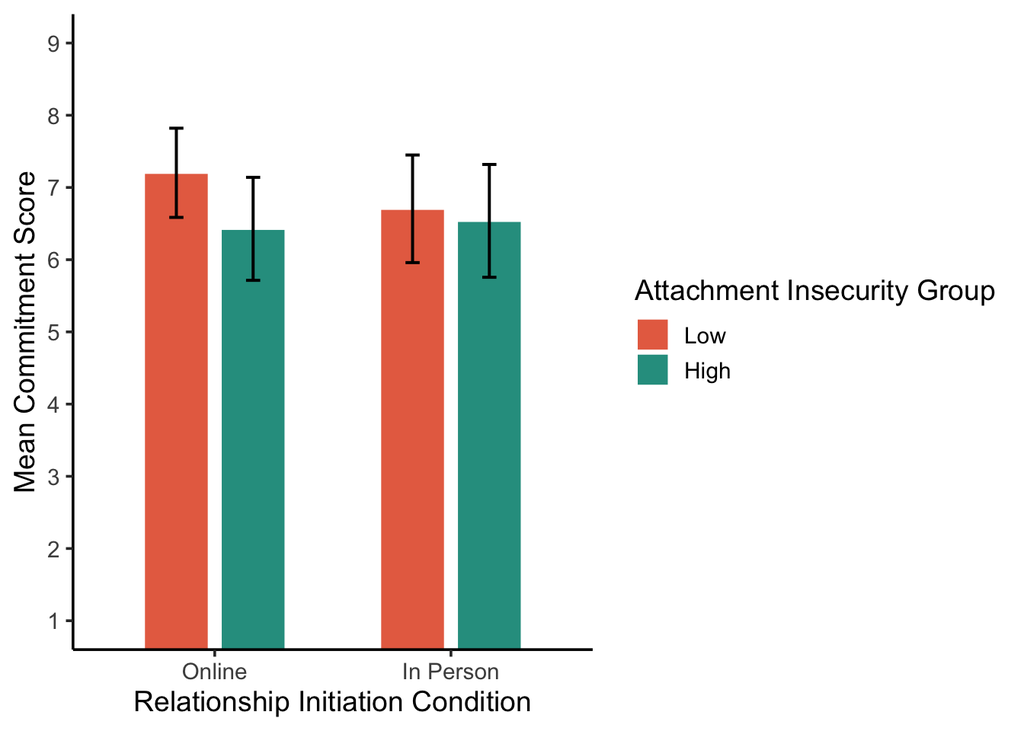

```r
p_total_ecrs_bar <- ggplot(
  as.data.frame(emmeans(a1_commitment, ~ condition * ECRS_msplit)),
  aes(
    x = condition,
    y = emmean,
    fill = ECRS_msplit
  )
) +
  geom_col(
    position = position_dodge(width = 0.65),
    width = 0.55,
    color = "white"
  ) +
  geom_errorbar(
    aes(
      ymin = lower.CL,
      ymax = upper.CL
    ),
    position = position_dodge(width = 0.65),
    width = 0.12,
    linewidth = 0.7
  ) +
  labs(
    x = "Relationship Initiation Condition",
    y = "Mean Commitment Score",
    fill = "Attachment Insecurity Group"
  ) +
  scale_fill_manual(
    values = c(
      "Low" = "#E76F51", # YOU CAN CHANGE THESE TWO HEX VALUES TO MATCH YOUR POSTER!
      "High" = "#2A9D8F"
    )
  ) +
  scale_y_continuous(
    breaks = seq(1, 9, 1)
  ) +
  coord_cartesian(
    ylim = c(1, 9)
  ) +
  theme_classic(
    base_size = 14
  )

p_total_ecrs_bar
```

*This figure displays commitment scores as a function of relationship initiation condition and overall attachment insecurity group. Participants with lower attachment insecurity generally reported higher commitment than those with higher attachment insecurity, although this difference was not statistically significant. The relatively parallel pattern of the bars across conditions is consistent with the non-significant interaction observed in the ANOVA, indicating that the effect of relationship initiation context on commitment did not depend on overall attachment insecurity.*

### Commitment (ECRS Anxiety) Interaction Plot

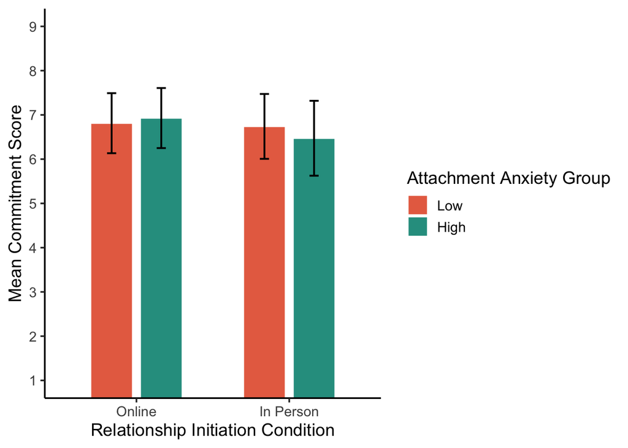

```r
p_anxiety_bar <- ggplot(
  as.data.frame(emmeans(a2_commitment_anxiety, ~ condition * ECRS_anxiety_msplit)),
  aes(
    x = condition,
    y = emmean,
    fill = ECRS_anxiety_msplit
  )
) +
  geom_col(
    position = position_dodge(width = 0.65),
    width = 0.55,
    color = "white"
  ) +
  geom_errorbar(
    aes(
      ymin = lower.CL,
      ymax = upper.CL
    ),
    position = position_dodge(width = 0.65),
    width = 0.12,
    linewidth = 0.7
  ) +
  labs(
    x = "Relationship Initiation Condition",
    y = "Mean Commitment Score",
    fill = "Attachment Anxiety Group"
  ) +
  scale_fill_manual(
    values = c(
      "Low" = "#E76F51",
      "High" = "#2A9D8F"
    )
  ) +
  scale_y_continuous(
    breaks = seq(1, 9, 1)
  ) +
  coord_cartesian(
    ylim = c(1, 9)
  ) +
  theme_classic(
    base_size = 14
  )

p_anxiety_bar
```

*This figure presents commitment scores across relationship initiation conditions and attachment anxiety groups. Participants with low and high attachment anxiety reported very similar levels of commitment in both the online and in-person conditions. The substantial overlap in confidence intervals and similar bar heights are consistent with the non-significant main effect of attachment anxiety and the non-significant interaction between attachment anxiety and relationship initiation context.*

### Commitment (ECRS Avoidance) Interaction Plot

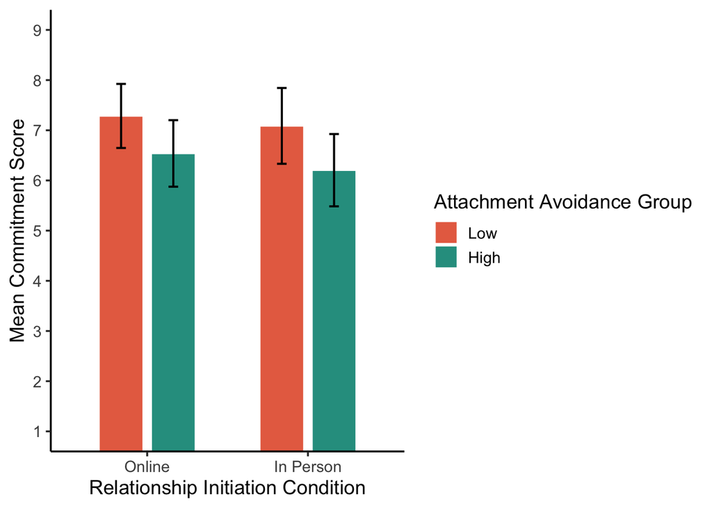

```r
p_avoidance_bar <- ggplot(
  as.data.frame(emmeans(a3_commitment_avoidance, ~ condition * ECRS_avoidance_msplit)),
  aes(
    x = condition,
    y = emmean,
    fill = ECRS_avoidance_msplit
  )
) +
  geom_col(
    position = position_dodge(width = 0.65),
    width = 0.55,
    color = "white"
  ) +
  geom_errorbar(
    aes(
      ymin = lower.CL,
      ymax = upper.CL
    ),
    position = position_dodge(width = 0.65),
    width = 0.12,
    linewidth = 0.7
  ) +
  labs(
    x = "Relationship Initiation Condition",
    y = "Mean Commitment Score",
    fill = "Attachment Avoidance Group"
  ) +
  scale_fill_manual(
    values = c(
      "Low" = "#E76F51",
      "High" = "#2A9D8F"
    )
  ) +
  scale_y_continuous(
    breaks = seq(1, 9, 1)
  ) +
  coord_cartesian(
    ylim = c(1, 9)
  ) +
  theme_classic(
    base_size = 14
  )

p_avoidance_bar
```

*This figure displays commitment scores across relationship initiation conditions and attachment avoidance groups. Participants with low attachment avoidance reported higher commitment scores than participants with high attachment avoidance in both relationship initiation conditions. This pattern is consistent with the significant main effect of attachment avoidance observed in the ANOVA. However, the similar differences across the online and in-person conditions indicate that attachment avoidance did not interact with relationship initiation context, supporting the non-significant interaction effect.*

### Export Figures

```r
#if (!dir.exists("figures")) {
 # dir.create("figures")
#}

#ggsave(
 # filename = "figures/total_ecrs_interaction_plot.svg",
  #plot = p_total_ecrs_bar,
  #width = 7,
  #height = 5
#)

#ggsave(
 # filename = "figures/anxiety_interaction_plot.svg",
#  plot = p_anxiety_bar,
 # width = 7,
#  height = 5
#)

#ggsave(
 # filename = "figures/avoidance_interaction_plot.svg",
#  plot = p_avoidance_bar,
 # width = 7,
 # height = 5
#)
```

## Results Summary

*The primary goal of this study was to examine whether relationship initiation context and attachment style influenced willingness to commit in romantic relationships. Overall, participants reported similar levels of commitment regardless of whether the relationship began online or in person. General attachment insecurity and attachment anxiety were not associated with differences in commitment. However, attachment avoidance emerged as an important predictor of commitment, with individuals low in attachment avoidance reporting greater willingness to commit than individuals high in attachment avoidance. These findings suggest that personal attachment characteristics, particularly avoidance, may play a greater role in romantic commitment than the context in which a relationship begins.*